```python
# Installation
!pip install matplotlib
```

# What is Matplotlib?

- Matplotlib is a Python visualization library used to create static, animated, and interactive charts.

It is one of the most powerful plotting libraries and forms the foundation of other tools.

# Why is Matplotlib Used?

Matplotlib is used for:

1. Visualizing trends and patterns in data
2. Creating scientific and statistical charts
3. Building dashboards and reports
4. Data exploration during machine learning
5. Publishing-quality graphics for presentations
6. Customizing every single element of a chart

# Matplotlib Architecture (Important)

Matplotlib follows a layered architecture:

(1) Figure

The full window or page where all charts are drawn.

(2) Axes

The actual plotting area inside the figure. Each subplot is one Axes.

(3) Axis

The x-axis and y-axis.

(4) Artist

Objects like:

```
lines
bars
legends
markers
```

```python
import pandas as pd
df1 = pd.read_csv('/content/50_Startups.csv')
df1.head(2)
```

|  | RND | ADMIN | MKT | STATE | PROFIT |
| --- | --- | --- | --- | --- | --- |
| 0 | 165349.2 | 136897.80 | 471784.10 | New York | 192261.83 |
| 1 | 162597.7 | 151377.59 | 443898.53 | California | 191792.06 |

# 1. LINE CHART

- A line chart is used to show the trend of a numeric variable over time or continuous changes.

### Purpose / When to Use

- To show growth, decline, or pattern changes
- To analyze time-series data
- To observe continuous variation

### Key Characteristics

- X-axis → Usually time
- Y-axis → Numeric values
- Uses continuous connected line segments

### Advantages

- Excellent for showing trends
- Easy to compare multiple lines
- Simple and readable

### Real-World Uses

- Sales trend over months
- Stock prices over time
- Temperature trend during a day

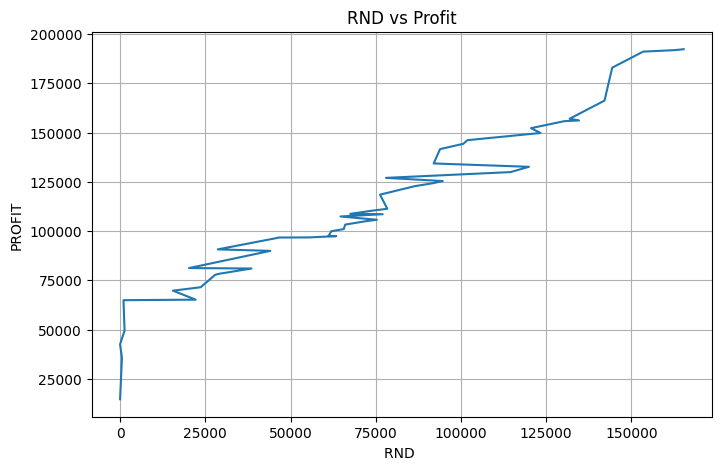

```python
# Line Plot.
import matplotlib.pyplot as plt
plt.figure(figsize=(8,5))
plt.plot(df1['RND'],df1['PROFIT'])
plt.title("RND vs Profit")
plt.xlabel("RND ")
plt.ylabel("PROFIT")
plt.grid()
plt.show()
```

# 2. BAR CHART (Vertical Bar)

- A bar chart uses vertical bars to compare values across different categories.

### Purpose / When to Use

- To compare categorical data
- To analyze highest, lowest, or differences between categories

### Key Characteristics

- Bars stand vertically
- Height = value
- Best for nominal or categorical data

### Advantages

- Easy to compare multiple categories
- Clear visual differences
- Works well with small and large categories

### Real-World Uses

- Profit by State
- Sales by Category
- Cars by Manufacturer count

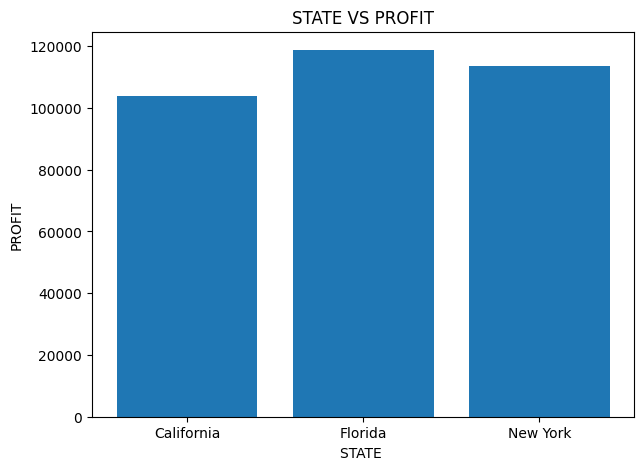

```python
# Bar Chart - Average profit per state.
state_profit = df1.groupby('STATE')['PROFIT'].mean()

plt.figure(figsize=(7,5))
plt.bar(state_profit.index, state_profit.values)
plt.title("STATE VS PROFIT")
plt.xlabel("STATE ")
plt.ylabel("PROFIT")
plt.show()
```

# 3. SCATTER PLOT

- A scatter plot shows the relationship between two numeric variables using dots.

### Purpose / When to Use

- To identify correlation (positive/negative)
- To detect patterns, clusters, or outliers

### Key Characteristics

- Each point represents one observation
- X vs Y numeric comparison
- No lines connecting points

### Advantages

- Best for correlation analysis
- Highlights outliers clearly
- Shows data distribution effectively

### Real-World Uses

- R&D Spend vs Profit
- Age vs Salary
- Horsepower vs Mileage (Cars93)

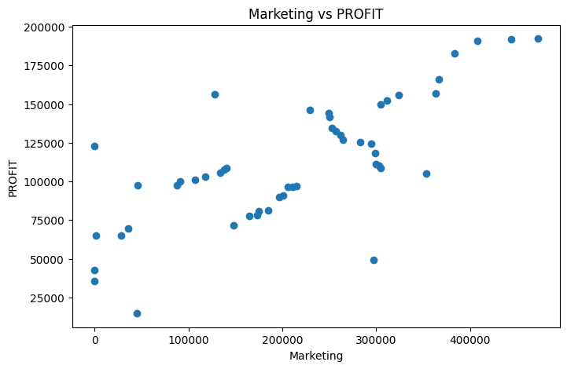

```python
# Scatter Plot - Marketing vs PROFIT
# showing correlations.
# Identifying outliers.

plt.figure(figsize=(8,5))
plt.scatter(df1['MKT'], df1['PROFIT'])
plt.title("Marketing vs PROFIT")
plt.xlabel("Marketing")
plt.ylabel("PROFIT")
plt.show()
```

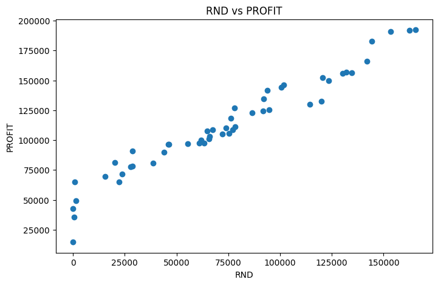

```python
plt.figure(figsize=(8,5))
plt.scatter(df1['RND'], df1['PROFIT'])
plt.title("RND vs PROFIT")
plt.xlabel("RND")
plt.ylabel("PROFIT")
plt.show()
```

## **corr()** stands for Correlation, which measures how strongly two numerical variables are related to each other.

- It returns a value between:

+1 → Strong Positive Relationship, 0 → No Relationship, –1 → Strong Negative Relationship

- Where It Is Used
1. Feature selection
2. Identifying strong predictors
3. Multicollinearity detection
4. Exploratory Data Analysis (EDA)

```python
df1['MKT'].corr(df1['PROFIT'])
```

```
np.float64(0.7477657217414767)
```

```python
df1['ADMIN'].corr(df1['PROFIT'])
```

```
np.float64(0.20071656826872128)
```

```python
df1['RND'].corr(df1['PROFIT'])
```

```
np.float64(0.9729004656594832)
```

# 4. HISTOGRAM

- A histogram shows the frequency distribution of a numeric variable by grouping data into bins.

### Purpose / When to Use

- To understand distribution
- To see skewness, spread, shape
- To find patterns in continuous numeric data

### Key Characteristics

- Bars touch each other
- X-axis contains bins (intervals)
- Y-axis shows frequency count

### Advantages

- Best for distribution analysis
- Detect outliers and skew
- Helps understand spread of data

### Real-World Uses

- Age distribution
- Salary distribution
- Car horsepower distribution

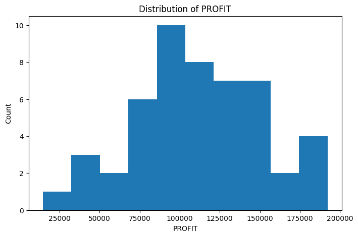

```python
# Histogram - Distribution of PROFIT.
import matplotlib.pyplot as plt
plt.figure(figsize=(8,5))
plt.hist(df1['PROFIT'],bins=10)
plt.title("Distribution of PROFIT")
plt.xlabel('PROFIT')
plt.ylabel("Count")
plt.show()
```

```python
df1.head()
```

|  | RND | ADMIN | MKT | STATE | PROFIT |
| --- | --- | --- | --- | --- | --- |
| 0 | 165349.20 | 136897.80 | 471784.10 | New York | 192261.83 |
| 1 | 162597.70 | 151377.59 | 443898.53 | California | 191792.06 |
| 2 | 153441.51 | 101145.55 | 407934.54 | Florida | 191050.39 |
| 3 | 144372.41 | 118671.85 | 383199.62 | New York | 182901.99 |
| 4 | 142107.34 | 91391.77 | 366168.42 | Florida | 166187.94 |

# 5. BOXPLOT

- A boxplot shows the spread, distribution, and outliers of a numeric dataset using five summary points:

  ```
        Minimum
        Q1 (25%)
        Median (50%)
        Q3 (75%)
        Maximum
  ```

### Purpose / When to Use

```
        To detect outliers
        To understand distribution
        To compare multiple groups
```

### Key Characteristics

```
        Box = IQR (Interquartile Range)
        Line inside box = median
        Whiskers = range
        Dots = outliers
```

### Advantages

```
        Best for comparing distributions
        Great for identifying extreme values
```

### Real-World Uses

```
        Profit distribution
        Salary comparison
        Engine size variation across car types
```

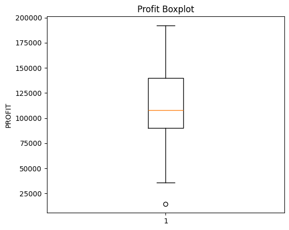

```python
# Boxplot - Profit for Outlier Detection.
# Finding outliers.
# Checking spread and median.
plt.figure(figsize=(6,5))
plt.boxplot(df1['PROFIT'])
plt.title("Profit Boxplot")
plt.ylabel('PROFIT')
plt.show()
```

# 6. HORIZONTAL BAR CHART

- A horizontal bar chart uses horizontal bars instead of vertical bars.

### Purpose / When to Use

- When category labels are long
- When you want readability
- For ranking items from smallest to largest

### Key Characteristics

- Bars move left → right
- Length of bar = value
- Ideal for categorical comparison

### Advantages

- Better readabilit
- Works well for top 10 or top 20 lists
- Handles long labels easily

### Real-World Uses

- Top 10 highest priced cars
- Country names comparison
- Product names comparison

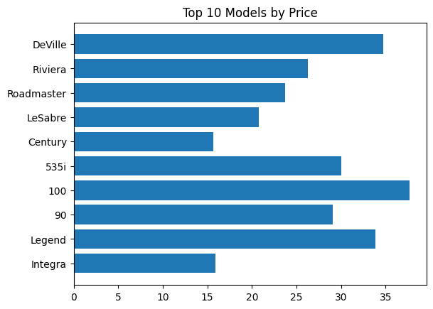

```python
import matplotlib.pyplot as plt

plt.barh(df['Model'][:10], df['Price'][:10])
plt.title("Top 10 Models by Price")
plt.show()
```

# 7. PIE CHART

- A pie chart displays parts of a whole as slices of a circle.

### Purpose / When to Use

- To show percentage contribution
- To compare shares of a whole

### Key Characteristics

- 360° circle
- Each slice = category share
- Works best with limited categories (3–7)

### Advantages

- Good for quick percentage understanding
- Simple and visually appealing

### Real-World Uses

- Market share
- Sales percentage by region
- Car types proportion

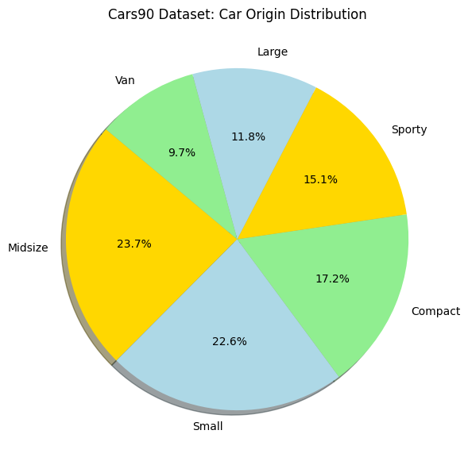

```python
origin_counts = df['Type'].value_counts()

plt.figure(figsize=(7,7))
plt.pie(
    origin_counts,
    labels=origin_counts.index,
    autopct="%1.1f%%",
    startangle=140,
    shadow=True,
    colors=["gold", "lightblue", "lightgreen"]
)

plt.title("Cars90 Dataset: Car Origin Distribution")
plt.show()
```

# What Is a Subplot?

- A subplot means displaying multiple plots inside one single figure.

### It is helpful when you want to:

- Compare multiple charts side-by-side
- Show different variables in one view
- Create dashboards
- Visualize distributions, trends, and relationships together

### Why Use Subplots?

- Create dashboards
- Compare multiple variables
- Save space in reports
- Provide professional visualizations
- Show relationships and patterns in one figure

```python
import pandas as pd
df = pd.read_csv('/content/Cars93.csv')
df.head()
```

|  | id | Manufacturer | Model | Type | Min.Price | Price | Max.Price | MPG.city | MPG.highway | AirBags | ... | Passengers | Length | Wheelbase | Width | Turn.circle | Rear.seat.room | Luggage.room | Weight | Origin | Make |
| --- | --- | --- | --- | --- | --- | --- | --- | --- | --- | --- | --- | --- | --- | --- | --- | --- | --- | --- | --- | --- | --- |
| 0 | 1 | Acura | Integra | Small | 12.9 | 15.9 | 18.8 | 25 | 31 | NaN | ... | 5 | 177 | 102 | 68 | 37 | 26.5 | 11.0 | 2705 | non-USA | Acura Integra |
| 1 | 2 | Acura | Legend | Midsize | 29.2 | 33.9 | 38.7 | 18 | 25 | Driver & Passenger | ... | 5 | 195 | 115 | 71 | 38 | 30.0 | 15.0 | 3560 | non-USA | Acura Legend |
| 2 | 3 | Audi | 90 | Compact | 25.9 | 29.1 | 32.3 | 20 | 26 | Driver only | ... | 5 | 180 | 102 | 67 | 37 | 28.0 | 14.0 | 3375 | non-USA | Audi 90 |
| 3 | 4 | Audi | 100 | Midsize | 30.8 | 37.7 | 44.6 | 19 | 26 | NaN | ... | 6 | 193 | 106 | 70 | 37 | 31.0 | 17.0 | 3405 | non-USA | Audi 100 |
| 4 | 5 | BMW | 535i | Midsize | 23.7 | 30.0 | 36.2 | 22 | 30 | Driver only | ... | 4 | 186 | 109 | 69 | 39 | 27.0 | 13.0 | 3640 | non-USA | BMW 535i |

5 rows × 28 columns

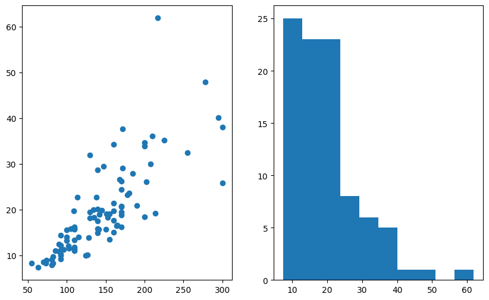

```python
# Subplot
plt.figure(figsize=(10,6))

plt.subplot(1,2,1)
plt.scatter(x=df['Horsepower'], y=df['Price'])

plt.subplot(1,2,2)
plt.hist(df['Price'])

plt.show()
```

# STYLING (Colors, Linestyles, Markers)

- Styling controls how your chart looks:

  ```
    Line colors
    Line style (dotted, dashed)
    Point markers (circle, star)
  ```

| Parameter | Examples |
| --- | --- |
| `color` | "red", "blue", "green", "#FF5733" |
| `linestyle` | "-", "--", "-.", ":" |
| `marker` | "o", "s", "*", "x" |

# LEGENDS

- Legend explains which color/line belongs to which label.

### Use When

- You have multiple lines or scatter groups
- Need to clarify categories

### Legend Position Options

```
"upper left"
"upper right"
"lower left"
"best" (automatic)
```

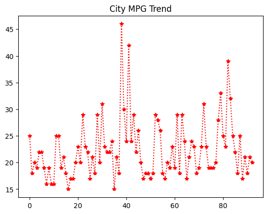

```python
from matplotlib.lines import lineStyles
plt.plot(df['MPG.city'], color = 'red',linestyle= ':', marker = '*')
plt.title('City MPG Trend')
plt.grid(False)
plt.show()
```

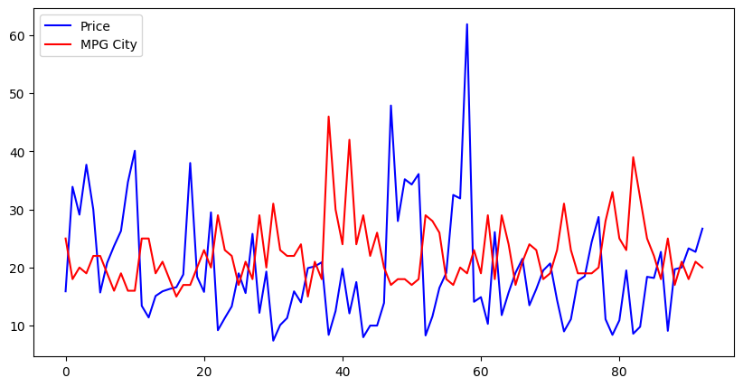

```python
# Two Line Charts

plt.figure(figsize=(10,5))
plt.plot(df['Price'], label = 'Price', color='blue')
plt.plot(df['MPG.city'], label='MPG City', color='Red')
plt.legend(loc="upper left")
plt.show()
```

# Value and Frequency Based Functions

1. df.value_counts()
- Shows count of each category.
2. df.unique()
- Shows unique values.
3. df.nunique()
- Count of unique values.

```python
df['Type'].value_counts()
```

| Type | count |
| --- | --- |
| Midsize | 22 |
| Small | 21 |
| Compact | 16 |
| Sporty | 14 |
| Large | 11 |
| Van | 9 |

**dtype:** int64

```python
df['AirBags'].unique()
```

```
array([nan, 'Driver & Passenger', 'Driver only'], dtype=object)
```

```python
df['AirBags'].nunique()
```

```
2
```

```python
# df.quantile() :- Used for percentiles.

df['Price'].quantile(0.25)   # 25th percentile
df['Price'].quantile(0.75)   # 75th percentile
```

```
np.float64(23.3)
```